# ULMFiT Sentiment Analysis

## Content

1. Description
2. Exploratory Data Analysis
   - Wordcloud of postive and negative tweets
   - Univariate Data Analysis
   - Bivariate Data Analysis

## 1. Description

This data originally came from Crowdflower's Data for Everyone library. It contains whether the sentiment of the tweets in this set was positive, neutral, or negative for six US airlines As the original source says,

> "A sentiment analysis job about the problems of each major U.S. airline. Twitter data was scraped from February of 2015 and contributors were asked to first classify positive, negative, and neutral tweets, followed by categorizing negative reasons (such as "late flight" or "rude service"). The data we're providing on Kaggle is a slightly reformatted version of the original source. It includes both a CSV file and SQLite database. The code that does these transformations is available on GitHub”

## 2. Exploratory Data Analysis (EDA)

#### Importing Libraries

```python
import numpy as np
import pandas as pd
import seaborn as sns
import matplotlib.pyplot as plt

from wordcloud import WordCloud, STOPWORDS
```

```python
sns.set()
sns.palplot(sns.color_palette())
%matplotlib inline
%config InlineBackend.figure_format='retina'
```

#### Data Preview

```python
df_data = pd.read_csv("..\data\Tweets.csv")
df_data
```

|  | tweet_id | airline_sentiment | airline_sentiment_confidence | negativereason | negativereason_confidence | airline | airline_sentiment_gold | name | negativereason_gold | retweet_count | text | tweet_coord | tweet_created | tweet_location | user_timezone |
| --- | --- | --- | --- | --- | --- | --- | --- | --- | --- | --- | --- | --- | --- | --- | --- |
| 0 | 570306133677760513 | neutral | 1.0000 | NaN | NaN | Virgin America | NaN | cairdin | NaN | 0 | @VirginAmerica What @dhepburn said. | NaN | 2015-02-24 11:35:52 -0800 | NaN | Eastern Time (US & Canada) |
| 1 | 570301130888122368 | positive | 0.3486 | NaN | 0.0000 | Virgin America | NaN | jnardino | NaN | 0 | @VirginAmerica plus you've added commercials t... | NaN | 2015-02-24 11:15:59 -0800 | NaN | Pacific Time (US & Canada) |
| 2 | 570301083672813571 | neutral | 0.6837 | NaN | NaN | Virgin America | NaN | yvonnalynn | NaN | 0 | @VirginAmerica I didn't today... Must mean I n... | NaN | 2015-02-24 11:15:48 -0800 | Lets Play | Central Time (US & Canada) |
| 3 | 570301031407624196 | negative | 1.0000 | Bad Flight | 0.7033 | Virgin America | NaN | jnardino | NaN | 0 | @VirginAmerica it's really aggressive to blast... | NaN | 2015-02-24 11:15:36 -0800 | NaN | Pacific Time (US & Canada) |
| 4 | 570300817074462722 | negative | 1.0000 | Can't Tell | 1.0000 | Virgin America | NaN | jnardino | NaN | 0 | @VirginAmerica and it's a really big bad thing... | NaN | 2015-02-24 11:14:45 -0800 | NaN | Pacific Time (US & Canada) |
| ... | ... | ... | ... | ... | ... | ... | ... | ... | ... | ... | ... | ... | ... | ... | ... |
| 14635 | 569587686496825344 | positive | 0.3487 | NaN | 0.0000 | American | NaN | KristenReenders | NaN | 0 | @AmericanAir thank you we got on a different f... | NaN | 2015-02-22 12:01:01 -0800 | NaN | NaN |
| 14636 | 569587371693355008 | negative | 1.0000 | Customer Service Issue | 1.0000 | American | NaN | itsropes | NaN | 0 | @AmericanAir leaving over 20 minutes Late Flig... | NaN | 2015-02-22 11:59:46 -0800 | Texas | NaN |
| 14637 | 569587242672398336 | neutral | 1.0000 | NaN | NaN | American | NaN | sanyabun | NaN | 0 | @AmericanAir Please bring American Airlines to... | NaN | 2015-02-22 11:59:15 -0800 | Nigeria,lagos | NaN |
| 14638 | 569587188687634433 | negative | 1.0000 | Customer Service Issue | 0.6659 | American | NaN | SraJackson | NaN | 0 | @AmericanAir you have my money, you change my ... | NaN | 2015-02-22 11:59:02 -0800 | New Jersey | Eastern Time (US & Canada) |
| 14639 | 569587140490866689 | neutral | 0.6771 | NaN | 0.0000 | American | NaN | daviddtwu | NaN | 0 | @AmericanAir we have 8 ppl so we need 2 know h... | NaN | 2015-02-22 11:58:51 -0800 | dallas, TX | NaN |

14640 rows × 15 columns

```python
features = df_data.columns
xtics = []
for col in features:
    xtics.append([col, df_data[col].nunique(), sum(df_data[col].notnull()), df_data[col].dtypes])


summary = pd.DataFrame(xtics, columns=["Feature", "Unique Values", "Non-Nulls", "Data Type"])
summary.style.hide_index()
```

| Feature | Unique Values | Non-Nulls | Data Type |
| --- | --- | --- | --- |
| tweet_id | 14485 | 14640 | int64 |
| airline_sentiment | 3 | 14640 | object |
| airline_sentiment_confidence | 1023 | 14640 | float64 |
| negativereason | 10 | 9178 | object |
| negativereason_confidence | 1410 | 10522 | float64 |
| airline | 6 | 14640 | object |
| airline_sentiment_gold | 3 | 40 | object |
| name | 7701 | 14640 | object |
| negativereason_gold | 13 | 32 | object |
| retweet_count | 18 | 14640 | int64 |
| text | 14427 | 14640 | object |
| tweet_coord | 832 | 1019 | object |
| tweet_created | 14247 | 14640 | object |
| tweet_location | 3081 | 9907 | object |
| user_timezone | 85 | 9820 | object |

### 2.1. Wordcloud of postive and negative tweets

```python
ps_df = df_data[df_data['airline_sentiment']=='positive']
pv_words = ' '.join(ps_df['text'])
pv_word = ' '.join([word for word in pv_words.split() if 'http' not in word and not word.startswith('@') and word != 'RT' ])
pv_wordcloud = WordCloud(stopwords=STOPWORDS, background_color='blue').generate(pv_word)

nn_df=df_data[df_data['airline_sentiment']=='neutral']
nn_words = ' '.join(nn_df['text'])
nn_word = ' '.join([word for word in nn_words.split() if 'http' not in word and not word.startswith('@') and word != 'RT' and word !='wa'])
nn_wordcloud = WordCloud(stopwords=STOPWORDS, background_color='white').generate(nn_word)

nv_df=df_data[df_data['airline_sentiment']=='negative']
nv_words = ' '.join(nv_df['text'])
nv_word = ' '.join([word for word in nv_words.split() if 'http' not in word and not word.startswith('@') and word != 'RT' and word !='wa'])
nv_wordcloud = WordCloud(stopwords=STOPWORDS, background_color='pink').generate(nv_word)
```

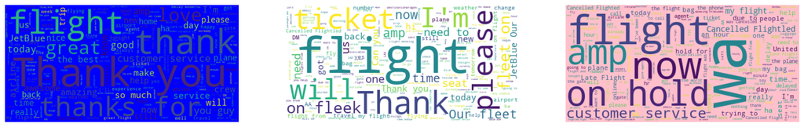

```python
plt.figure(figsize=(20,20))

plt.subplot(131)
plt.imshow(pv_wordcloud)
plt.axis('off')

plt.subplot(132)
plt.imshow(nn_wordcloud)
plt.axis('off')

plt.subplot(133)
plt.imshow(nv_wordcloud)
plt.axis('off')

plt.show()
```

### 2.1. Univariate Data Analysis

Looking at the table above we can see few features on interest that we can explore individually here ('airline_sentiment', 'negativereason', 'airline', 'retweet_count')

#### Airline Sentiment

- From the visual, it is fair to say that most passengers do not appreciate their flights.
- There are tweets of three types (postive, neutral and negative) in the ratio.

```python
df_data['airline_sentiment'].value_counts(normalize=True).round(2)*100
```

```
negative    63.0
neutral     21.0
positive    16.0
Name: airline_sentiment, dtype: float64
```

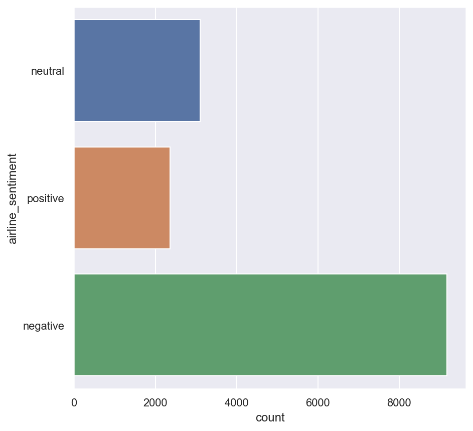

```python
plt.figure(figsize=(7,7))
sns.countplot(y="airline_sentiment", data=df_data)
```

#### Airline

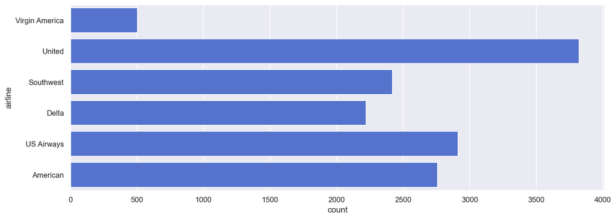

```python
plt.figure(figsize=(14,5))
sns.countplot(y='airline', data=df_data, color='royalblue')
```

#### Negative Reason

Clearly, most passengers complained about the customer service followed by late flights.

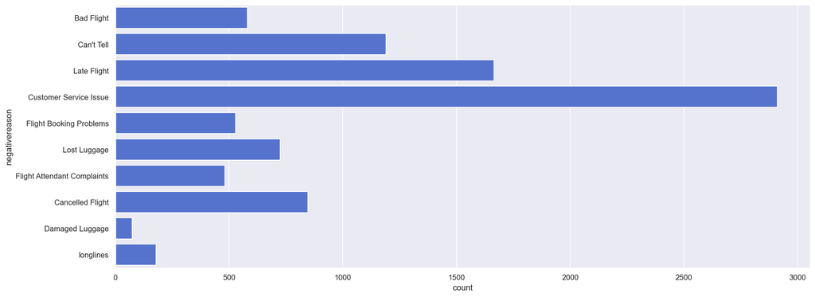

```python
plt.figure(figsize=(18,7))
sns.countplot(y="negativereason", data=df_data, color='royalblue')
```

#### Retweet Count

We can observe that there were a some tweets that were retweeted mostly once or twice. It will be interesting to explore why they were retweeted that often in relation to other features compared to other tweets.

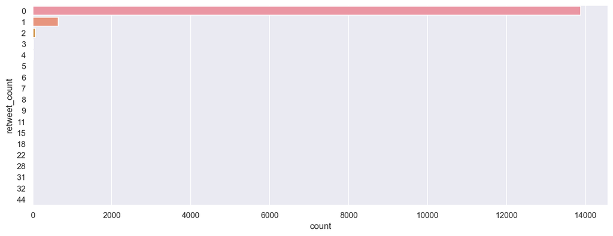

```python
plt.figure(figsize=(14,5))
sns.countplot(y="retweet_count", data=df_data)
```

### 2.2. Bivariate Data Analysis

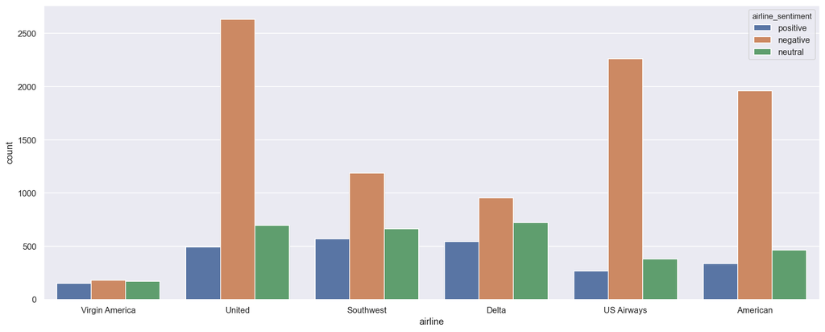

```python
plt.figure(figsize=(18,7))
sns.countplot(x='airline', hue='airline_sentiment', hue_order=['positive', 'negative', 'neutral'], data=df_data)
```

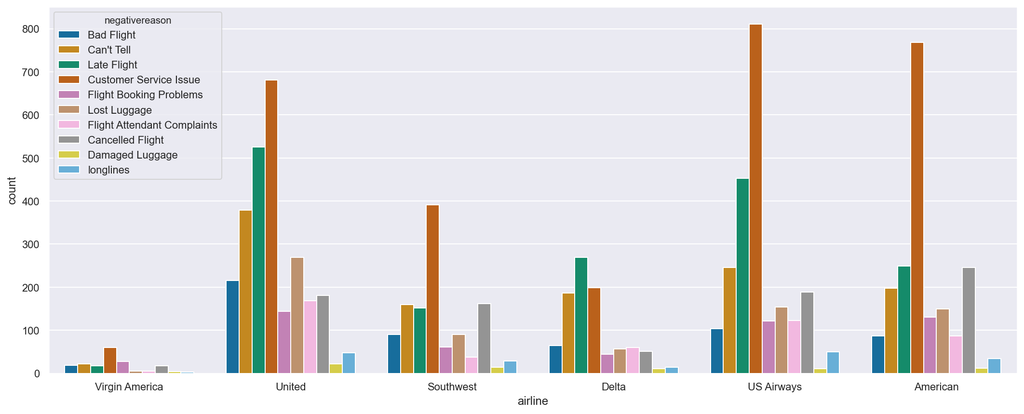

```python
plt.figure(figsize=(18,7))
sns.countplot(x='airline', hue='negativereason', data=df_data, palette='colorblind')
```

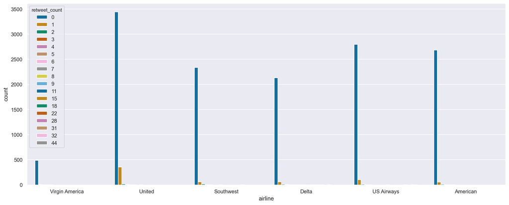

```python
plt.figure(figsize=(18,7))
sns.countplot(x='airline', hue='retweet_count', data=df_data, palette='colorblind')
```